# SI 370 - Homework #2: Data Visualization

## Background

This homework assignment focuses on the visual analysis of the COVID-19 data avaiable here: https://covid19datahub.io/articles/api/python.html. A description of the dataset can be found at https://covid19datahub.io/articles/doc/data.html

Your main task in this assignment is to explore the data *using the data manipulation, analysis, and visualization methods we covered in class* as well as those in the assigned readings. You may need to consult pandas and seaborn documentation, as well as Stack Overflow, or other online resources.

## Total Points and Rubric

Each question is worth 10 points. Points will be allocated according to the following rubric:

- 90-100%: Question is correctly and completely answered. Answer consists of well-written code that conforms to [PEP 8](https://www.python.org/dev/peps/pep-0008/) guidelines and is accompanied by a written interpretation in a Markdown block. Written interpretation does not contain spelling, grammar or stylistic errors (see https://faculty.washington.edu/heagerty/Courses/b572/public/StrunkWhite.pdf for a detailed specifications). Minor problems, such as formatting, incorrect submissions, missing names, etc. will result in less than 100%.
- 75-85% : Answer is mostly complete and correct; two or fewer noticeable omissions or errors. Minor stylistic flaws, either in code or in written interpretation.
- 50-70%: Answer has significant omissions or errors; Noticeable departure from PEP-8 guildelines and/or moderate spelling, grammar, or style issues in written interpretations.
- 25-45%: Question is perfunctorily attempted. Substantial parts are missing or incorrect.
- 0 points: Question not attempted.

## Getting the data

We used the COVID-19 datahub during the Day 6 in-class exercises. Therefore, you probably have the necessary module (covid19dh) installed from Day 6.

```python
from covid19dh import covid19
```

## Answer the questions below.

For each question, you should

1. Write code that can help you answer the following questions, and
2. Explain your answers in plain English. You should use complete sentences that would be understood by an educated professional who is not necessarily a data scientist (like a product manager).

```python
# Load all the modules
import pandas as pd
import numpy as np
import matplotlib.pyplot as plt
import seaborn as sns
%matplotlib inline
```

### Q1 How many different countries are represented in the country-level data set?

- Refer to the documentation to call the covid19() function with appropriate parameters (https://covid19datahub.io/articles/api/python.html)

```python
covid_data, src = covid19(verbose = False)
noc_regions = pd.read_csv('regions.csv')
noc_regions = noc_regions.rename(columns={'NOC': 'id'})
```

```python
#was excluding some countries so had to use different columns to merge the data

# merged = pd.merge(covid_data, noc_regions, on = 'id', how = 'inner')
# print(len(merged.id.unique()))
```

```python
print(len(noc_regions.id.unique()))
noc_regions.head()
covid_data.head()
```

```
230
```

|  | id | date | vaccines | tests | confirmed | recovered | deaths | hosp | vent | icu | ... | currency | administrative_area_level | administrative_area_level_1 | administrative_area_level_2 | administrative_area_level_3 | latitude | longitude | key | key_apple_mobility | key_google_mobility |
| --- | --- | --- | --- | --- | --- | --- | --- | --- | --- | --- | --- | --- | --- | --- | --- | --- | --- | --- | --- | --- | --- |
| 0 | AFG | 2020-01-22 | NaN | NaN | NaN | NaN | NaN | NaN | NaN | NaN | ... | AFN | 1 | Afghanistan | NaN | NaN | 33.0 | 65.0 | NaN | NaN | AF |
| 1 | AFG | 2020-01-23 | NaN | NaN | NaN | NaN | NaN | NaN | NaN | NaN | ... | AFN | 1 | Afghanistan | NaN | NaN | 33.0 | 65.0 | NaN | NaN | AF |
| 2 | AFG | 2020-01-24 | NaN | NaN | NaN | NaN | NaN | NaN | NaN | NaN | ... | AFN | 1 | Afghanistan | NaN | NaN | 33.0 | 65.0 | NaN | NaN | AF |
| 3 | AFG | 2020-01-25 | NaN | NaN | NaN | NaN | NaN | NaN | NaN | NaN | ... | AFN | 1 | Afghanistan | NaN | NaN | 33.0 | 65.0 | NaN | NaN | AF |
| 4 | AFG | 2020-01-26 | NaN | NaN | NaN | NaN | NaN | NaN | NaN | NaN | ... | AFN | 1 | Afghanistan | NaN | NaN | 33.0 | 65.0 | NaN | NaN | AF |

5 rows × 36 columns

```python
#merged the noc regions and covid data on administrative_area_level_1, used an inner join to only get values that are found in both
noc_regions = noc_regions.rename(columns={'region': 'administrative_area_level_1'})
merged_2 = pd.merge(covid_data, noc_regions, on = 'administrative_area_level_1', how = 'inner')
print(len(merged_2.administrative_area_level_1.unique()))
```

```
182
```

There are 182 countries represented in the dataframe.

### Q2 Create a line chart that shows the total number of cases over time.

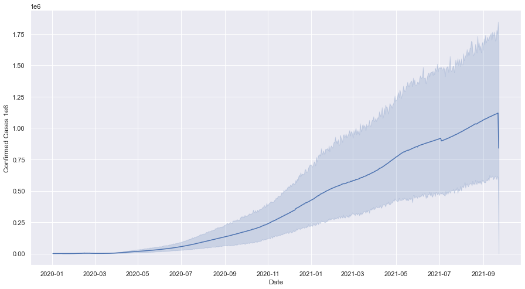

```python
sns.set(rc = {'figure.figsize':(15,8)})
sns.lineplot(x='date', y='confirmed', data = covid_data)
plt.xlabel("Date")
plt.ylabel("Confirmed Cases 1e6")
```

In the line chart above we can see that the number of confirmed cases gradually increases as the months go on in 2021.

### Q3 Use the country-level data set to create a histogram to:

- Show the distribution of values for the number of hospitalizations per 1000 people.
- Draw a red vertical line that shows the median value on the histogram.

```python
#first grouped by the region and got the max pop. and median hosp. because in the data description it mentions that they are cumulative
country_level = covid_data.groupby('administrative_area_level_1').agg({'population':'max', 'hosp':'median'})
country_level['hosp_per_1000'] = (country_level.hosp / country_level.population) * 1000
```

```python
#hosp = covid_data[covid_data['hosp'].notna()]
country_level['hosp_per_1000'].median()
# country_level.sample(10)
```

```
0.07298743827814899
```

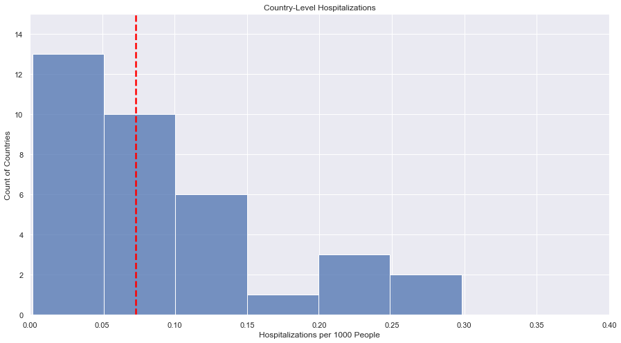

```python
sns.histplot(country_level["hosp_per_1000"]).set(xlim=(0,.4),ylim=(0,15))
plt.axvline(x=country_level['hosp_per_1000'].median(),
            color='red',
            ls='--',
            lw=2.5)
plt.xlabel("Hospitalizations per 1000 People")
plt.ylabel("Count of Countries")
plt.title('Country-Level Hospitalizations')
```

Here we see the distribution of hospitalizations per 1000 people and the count of the countries that are in that range. The red line signals the median of 0.072987. We can tell that as the ratio on the x axis increases the amount of contries in that range decreases.

### Q4 Create a visualization that shows the number of tests per day in the United States and indicate the median value on your visualization.

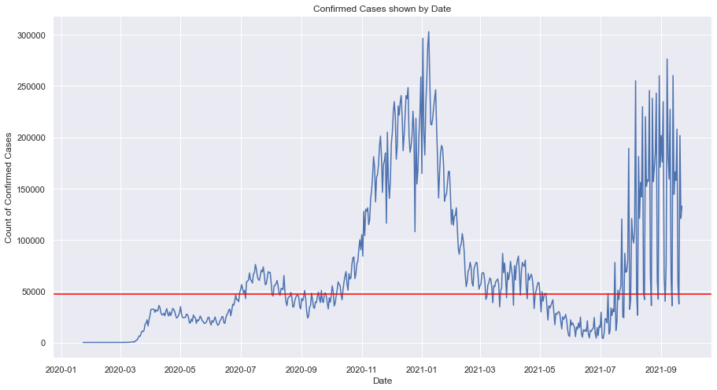

```python
#line graph
#first creates a df of jsut us data
us_covid = covid_data.loc[covid_data['id'] == 'USA']
us_covid.head()

#gets the difference because the data is cumulative in the raw sheet
us_covid['confirmed_per_day'] = us_covid['confirmed'].diff()

sns.lineplot(x='date', y='confirmed_per_day', data = us_covid)
plt.axhline(y=us_covid.confirmed_per_day.median(),
            color='red')
plt.xlabel("Date")
plt.ylabel("Count of Confirmed Cases")
plt.title('Confirmed Cases shown by Date')
```

```python
us_covid.confirmed_per_day.median()
```

```
47369.0
```

From the graph we are able to notice that the confimred cases spike in the time frame of 2020-11 - 2021-01. We then notice there to be a decrease in the cases followed by another upwards trend starting around 2021-07. The red line indicates a median of 47369.0 during the timeframe given by the data.